# Prediction

Jinhai_Yu

12/21/2020

## Summary

Using devices such as Jawbone Up, Nike FuelBand, and Fitbit it is now possible to collect a large amount of data about personal activity relatively inexpensively. These type of devices are part of the quantified self movement – a group of enthusiasts who take measurements about themselves regularly to improve their health, to find patterns in their behavior, or because they are tech geeks. One thing that people regularly do is quantify how much of a particular activity they do, but they rarely quantify how well they do it. In this project, I use the data of 6 participants, and perform 3 different model fit, including classification trees, random forest, and generalized boost. Among them, random forest gives the highest prediction accuracy, which might due to overfitting, which needs further test to validate. At last, use random forest model to predict the 20 test cases.

## Load libraries, load data

```r
library(caret)
library(ggplot2)
library(dplyr)
library(randomForest)
library(rattle)
test <- read.csv("testing.csv")
training <- read.csv("training.csv")
dim(test); dim(training); str(training)
```

```
## [1]  20 160
```

```
## [1] 19622   160
```

```
## 'data.frame':    19622 obs. of  160 variables:
##  $ X                       : int  1 2 3 4 5 6 7 8 9 10 ...
##  $ user_name               : chr  "carlitos" "carlitos" "carlitos" "carlitos" ...
##  $ raw_timestamp_part_1    : int  1323084231 1323084231 1323084231 1323084232 1323084232 1323084232 1323084232 1323084232 1323084232 1323084232 ...
##  $ raw_timestamp_part_2    : int  788290 808298 820366 120339 196328 304277 368296 440390 484323 484434 ...
##  $ cvtd_timestamp          : chr  "05/12/2011 11:23" "05/12/2011 11:23" "05/12/2011 11:23" "05/12/2011 11:23" ...
##  $ new_window              : chr  "no" "no" "no" "no" ...
##  $ num_window              : int  11 11 11 12 12 12 12 12 12 12 ...
##  $ roll_belt               : num  1.41 1.41 1.42 1.48 1.48 1.45 1.42 1.42 1.43 1.45 ...
##  $ pitch_belt              : num  8.07 8.07 8.07 8.05 8.07 8.06 8.09 8.13 8.16 8.17 ...
##  $ yaw_belt                : num  -94.4 -94.4 -94.4 -94.4 -94.4 -94.4 -94.4 -94.4 -94.4 -94.4 ...
##  $ total_accel_belt        : int  3 3 3 3 3 3 3 3 3 3 ...
##  $ kurtosis_roll_belt      : chr  "" "" "" "" ...
##  $ kurtosis_picth_belt     : chr  "" "" "" "" ...
##  $ kurtosis_yaw_belt       : chr  "" "" "" "" ...
```

[output cut: 86 more lines]

## Remove variables containing large amount of NA or non-necessary information

```r
## remove variables containing NA
toremove <- which(colSums(is.na(training) | training == "") > 0.9 * dim(training)[1])
length(toremove)
```

```
## [1] 100
```

```r
training_subset <- training[, -toremove]
test <- test[, -toremove]
## remove object information
training_subset <- training_subset[, -c(1:7)]
test <- test[, -c(1:7)]
dim(test); dim(training_subset)
```

```
## [1] 20 53
```

```
## [1] 19622    53
```

```r
## subset part of training data as validation data
set.seed(1221)
inTrain <- createDataPartition(training_subset$class, p = 0.7, list = FALSE)
train <- training_subset[inTrain, ]
test1 <- training_subset[-inTrain, ]
str(train); str(test)
```

```
## 'data.frame':    13737 obs. of  53 variables:
##  $ roll_belt           : num  1.42 1.48 1.45 1.42 1.42 1.43 1.45 1.42 1.42 1.48 ...
##  $ pitch_belt          : num  8.07 8.07 8.06 8.09 8.13 8.16 8.17 8.2 8.21 8.15 ...
##  $ yaw_belt            : num  -94.4 -94.4 -94.4 -94.4 -94.4 -94.4 -94.4 -94.4 -94.4 -94.4 ...
##  $ total_accel_belt    : int  3 3 3 3 3 3 3 3 3 3 ...
##  $ gyros_belt_x        : num  0 0.02 0.02 0.02 0.02 0.02 0.03 0.02 0.02 0 ...
##  $ gyros_belt_y        : num  0 0.02 0 0 0 0 0 0 0 0 ...
##  $ gyros_belt_z        : num  -0.02 -0.02 -0.02 -0.02 -0.02 -0.02 0 0 -0.02 0 ...
##  $ accel_belt_x        : int  -20 -21 -21 -22 -22 -20 -21 -22 -22 -21 ...
##  $ accel_belt_y        : int  5 2 4 3 4 2 4 4 4 4 ...
##  $ accel_belt_z        : int  23 24 21 21 21 24 22 21 21 23 ...
##  $ magnet_belt_x       : int  -2 -6 0 -4 -2 1 -3 -3 -8 0 ...
##  $ magnet_belt_y       : int  600 600 603 599 603 602 609 606 598 592 ...
##  $ magnet_belt_z       : int  -305 -302 -312 -311 -313 -312 -308 -309 -310 -305 ...
##  $ roll_arm            : num  -128 -128 -128 -128 -128 -128 -128 -128 -128 -129 ...
```

[output cut: 39 more lines]

```
## 'data.frame':    20 obs. of  53 variables:
##  $ roll_belt           : num  123 1.02 0.87 125 1.35 -5.92 1.2 0.43 0.93 114 ...
##  $ pitch_belt          : num  27 4.87 1.82 -41.6 3.33 1.59 4.44 4.15 6.72 22.4 ...
##  $ yaw_belt            : num  -4.75 -88.9 -88.5 162 -88.6 -87.7 -87.3 -88.5 -93.7 -13.1 ...
##  $ total_accel_belt    : int  20 4 5 17 3 4 4 4 4 18 ...
##  $ gyros_belt_x        : num  -0.5 -0.06 0.05 0.11 0.03 0.1 -0.06 -0.18 0.1 0.14 ...
##  $ gyros_belt_y        : num  -0.02 -0.02 0.02 0.11 0.02 0.05 0 -0.02 0 0.11 ...
##  $ gyros_belt_z        : num  -0.46 -0.07 0.03 -0.16 0 -0.13 0 -0.03 -0.02 -0.16 ...
##  $ accel_belt_x        : int  -38 -13 1 46 -8 -11 -14 -10 -15 -25 ...
##  $ accel_belt_y        : int  69 11 -1 45 4 -16 2 -2 1 63 ...
##  $ accel_belt_z        : int  -179 39 49 -156 27 38 35 42 32 -158 ...
##  $ magnet_belt_x       : int  -13 43 29 169 33 31 50 39 -6 10 ...
##  $ magnet_belt_y       : int  581 636 631 608 566 638 622 635 600 601 ...
##  $ magnet_belt_z       : int  -382 -309 -312 -304 -418 -291 -315 -305 -302 -330 ...
##  $ roll_arm            : num  40.7 0 0 -109 76.1 0 0 0 -137 -82.4 ...
```

[output cut: 39 more lines]

## Build Fit Models

### 1.Classification Trees; 2. Random Forest; 3. Genenralized Boost

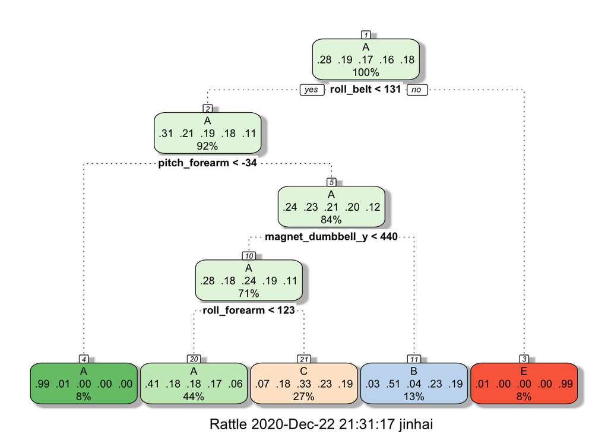

```r
# Classification Trees
modfit1 <- train(classe ~ ., data = train, method = "rpart")
fancyRpartPlot(modfit1$finalModel)
```

```r
pred1 <- predict(modfit1, newdata = test1)
confusionMatrix(pred1, as.factor(test1$classe))$overall[1]
```

```
## Accuracy
## 0.493288
```

```r
# Random Forest
RFcontrol <- trainControl(method = "cv", number = 5, repeats = 3)
modfit2 <- train(classe ~ ., data = train, method = "rf", trControl = RFcontrol)
modfit2$finalModel
```

```
##
## Call:
##  randomForest(x = x, y = y, mtry = param$mtry)
##                Type of random forest: classification
##                      Number of trees: 500
## No. of variables tried at each split: 27
##
##         OOB estimate of  error rate: 0.7%
## Confusion matrix:
##      A    B    C    D    E class.error
## A 3899    5    1    0    1 0.001792115
## B   19 2633    6    0    0 0.009405568
## C    0   13 2378    5    0 0.007512521
## D    0    1   30 2219    2 0.014653641
## E    0    1    6    6 2512 0.005148515
```

```r
pred2 <- predict(modfit2, newdata = test1)
confusionMatrix(pred2, as.factor(test1$classe))$overall[1]
```

```
##  Accuracy
## 0.9928632
```

```r
# Generalized Boost
modfit3 <- train(classe ~ ., data = train, method = "gbm", trControl = RFcontrol)
modfit3
```

```
## Stochastic Gradient Boosting
##
## 13737 samples
##    52 predictor
##     5 classes: 'A', 'B', 'C', 'D', 'E'
##
## No pre-processing
## Resampling: Cross-Validated (5 fold)
## Summary of sample sizes: 10990, 10989, 10990, 10990, 10989
## Resampling results across tuning parameters:
##
##   interaction.depth  n.trees  Accuracy   Kappa
##   1                   50      0.7499442  0.6827912
##   1                  100      0.8194652  0.7714143
##   1                  150      0.8531697  0.8141845
##   2                   50      0.8523685  0.8129068
##   2                  100      0.9058736  0.8808584
##   2                  150      0.9308430  0.9124895
##   3                   50      0.8944449  0.8663610
##   3                  100      0.9402337  0.9243761
##   3                  150      0.9595976  0.9488778
##
## Tuning parameter 'shrinkage' was held constant at a value of 0.1
##
## Tuning parameter 'n.minobsinnode' was held constant at a value of 10
## Accuracy was used to select the optimal model using the largest value.
## The final values used for the model were n.trees = 150, interaction.depth =
##  3, shrinkage = 0.1 and n.minobsinnode = 10.
```

```r
pred3 <- predict(modfit3, newdata = test1)
confusionMatrix(pred3, as.factor(test1$classe))$overall[1]
```

```
##  Accuracy
## 0.9631266
```

## Model selection

Based on the results, “Random Forest” gives the highest accuracy: 0.9929, while “rpart” only has 0.4933, and “gbm” results with 0.9631. We will choose modfit2 to predict test data.

## Predict test data

```r
pred4 <- predict(modfit2, newdata = test)
pred4
```

```
##  [1] B A B A A E D B A A B C B A E E A B B B
## Levels: A B C D E
```